# PROJET 1

Maxime ALEHE M2 IREF FQA

2023-10-13

# Introduction:

LMT représente l’action de l’entreprise Lockheed Martin, l’un des plus grands acteurs et fabricants d’avions de combat au monde, tels que le F-22 Raptor et le F-35 Lightning. Elle est née de la fusion en 1995 et a généré un chiffre d’affaires de 46 milliards de dollars américains en 2022. Plus de 60 % de son chiffre d’affaires provient de contrats de défense conclus avec l’administration américaine. Le cours de son action dépend fortement des décisions de l’administration américaine liées aux différentes guerres et tensions dans le monde. Ce travail se concentre sur l’évolution du cours de son action, pour lequel des tests statistiques seront effectués dans le but de mieux comprendre ses caractéristiques. Tout cela sera bien sûr étudié en relation avec l’activité et l’historique de l’entreprise sur la période allant de 2009 à août 2023.

# Etude descriptive:

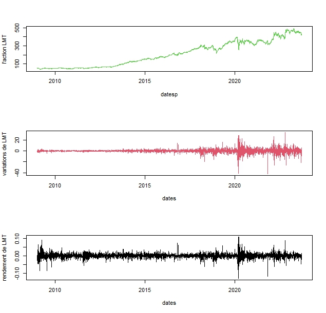

Fig 1

La figure 1 ci-dessus présente trois graphiques sur la période de 2009 à août 2023, représentant le cours de l’action LMT (en vert), sa variation (en rouge) et le rendement logarithmique (en noir). La série du cours de LMT montre une tendance globalement croissante sur la période considérée, avec des fluctuations plus ou moins importantes. On peut également observer une apparente hétéroscédasticité, notamment remarquable sur le graphique en rouge, avec des oscillations plus marquées autour de la période 2020-2021. Cela suggère immédiatement l’influence de la crise du COVID-19 autour de cette période.

La suite du travail sera concentrée sur le rendement logarithmique, sur lequel nous allons vérifier les 8 propriétés des rendements logarithmiques distinguées par Charpentier (2002). Pour ce faire, nous allons considérer deux périodes :

- Une première qui va du 5 janvier 2009 au 31 décembre 2017 inclus.
- Une deuxième qui commence en 2018.

# Propriété 1: Stationnarité

Dans cette partie, nous allons déterminer si le processus générateur de données (PGD) est stationnaire. On dit qu’une série est engendrée par un PGD stationnaire lorsque ses valeurs à une date sont une combinaison linéaire des valeurs passées et que ses coefficients sont constants dans le temps.

Définition : Un processus est dit stationnaire si les conditions suivantes sont vérifiées : $y_t ,t \in \mathbb{R}$ , $\forall t \in \mathbb{Z}$

- $E(y_t)= \mu$ moyenne indépendante du temps
- $Var(y_t)< \infty$ variance finie
- $cov(y_t, y-{t+h}= E[(y_{t+h}-\mu)(y_t-\mu)]=\gamma(h)$ autocovariance indépendante du temps

Nous allons effectuer des tests de racine unitaire pour déterminer la stationnarité de notre série.

## Test de dickey-fuller :

Spécification de la serie: spécification “**drift**” : Il existe une constante mais pas de tendance dans notre serie $y_t$. $\Delta Y_t =(\rho − 1)Y_{t−1}+\beta_0+\epsilon_t$ On test la significativité de $(\rho -1)$ et $\beta_0$.

Les hypothèses: $H_0 : \rho-1 = 0$ et $\beta_0$ versus $H_a: |\rho|< 0$ et $\beta_0\neq0$

On voit que $\beta_0$ est significative pvalue=0.00105 < 5%. donc cette régression est la bonne et donc le t calculé de $(\rho-1)$ tcalculé= -50.2509 < -2.86 on rejette H0.On conclut que le PGD est stationnaire. Il peut donc s’écrire $y_t$~$I(0)$. Parcontre, nous ne pouvons pas conclure définitivement à ce stade. La raison en est que, les résultats du test de Dickey-Fuller sont fiables uniquement lorsque les résidus ne présentent pas d’autocorrélation.

Pour plus d’informations sur les autres spécifications non retenues, veuillez consulter l’annexe (cliquez ici).

## Test d’autocorrélation sur les aleas:

**Test de l’autocorrelation sur les residus : ACF et PACF**

ACF est Fonction d’autocorrélation totale qui regroupe les coefficients d’autocorrélation totale.

PACF est la fonction d’autocorrélation partielle qui regroupe tous les coefficients d’autocorrélation partielle

Soit la fonction d’autocorrélation totale au retard $k$, $\rho(k)$ $\rho(k)= \gamma(k)/ \gamma(0)$ avec $\gamma_k= cov(rte_t,rte_{t-k})= E[(rte_t-\mu)(rte_{t-k}-\mu)]$

Le graphique de l’ACF nommé corrélogramme, présente dans un interval de confiance asymptotique à 95% des ρ(h), les deux lignes entre les barres sur le graphique représentent l’intervalle de confiance.

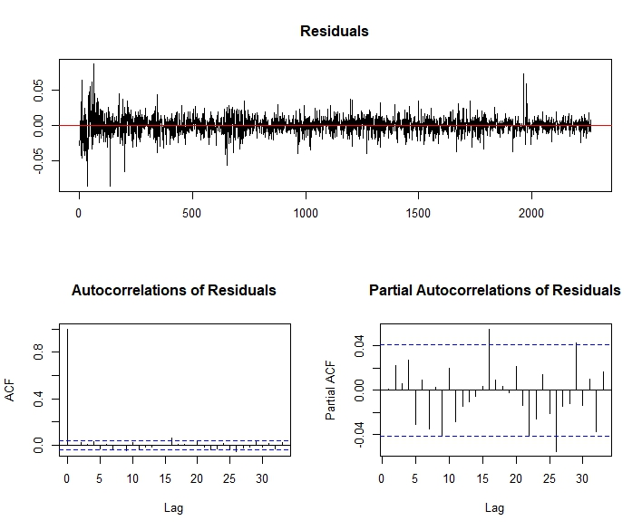

Fig2

## Test de Dickey Fuller Augmenté (ADF)

Le test est fait en gardant la spécification avec qui fluctue autour d’une valeur (la constante) non nulle “**drift”** retenue précédenment pour DF en introduisant p variables explicatives additionnelles pour tenir compte de l’autocorrélation:$\Delta Y_t= (\rho-1)Y_{t-1}+ \beta_0+ \sum_{p=1}^P \gamma_p\Delta_{t-1}+ \epsilon_t$

On test toujours la signifivativité de $\rho-1$ et $\beta_0$ en tenant compte de l’autocorrélation des aleas avec un nombre de retard, estimé avant le test.

Les hypothèses: $H_0 : \rho-1 = 0$ et $\beta_0$ versus $H_a: |\rho|< 0$ et $\beta_0 \neq 0$

**Nombre de retards P** : estimé par le critère du MAIC de NG et Perrons avec (2001) donc les formules sont les suivants:

$MAIC(p)=ln(\hat{\sigma}^2)+2 \frac{(\tau_T(p)+p)}{(T-pmax)}$

$\tau_T(P)= \frac{\hat{\alpha_0}^2 \sum_{t=pmax+1} y_{t-1}}{\hat{\sigma}^2}$

$\hat{\sigma}^2= 1/(T-pmax)*\sum_{t=pmax+1}^T e_t^2$

$pmax=12*(T/100)^{0,25}$

```
Augmented DF test
                                                ADF test
t-test statistic:                          -2.285088e+01
p-value:                                    8.917737e-48
Max lag of the diff. dependent variable:    3.000000e+00

Call:
dynlm(formula = formula(model), start = obs.1, end = obs.T)

Residuals:
      Min        1Q    Median        3Q       Max
-0.084738 -0.006332 -0.000041  0.006522  0.085952

Coefficients:
              Estimate Std. Error t value Pr(>|t|)
(Intercept)  0.0008289  0.0002566   3.230  0.00126 **
L(y, 1)     -0.9802138  0.0428961 -22.851  < 2e-16 ***
L(d(y), 1)  -0.0565661  0.0371034  -1.525  0.12751
L(d(y), 2)  -0.0267188  0.0304086  -0.879  0.37968
L(d(y), 3)  -0.0370219  0.0210723  -1.757  0.07907 .
---
Signif. codes:  0 ‘***’ 0.001 ‘**’ 0.01 ‘*’ 0.05 ‘.’ 0.1 ‘ ’ 1

Residual standard error: 0.01202 on 2232 degrees of freedom
Multiple R-squared:  0.5206,    Adjusted R-squared:  0.5197
F-statistic: 1.869 on 3 and 2232 DF,  p-value: 0.1327
```

**Commentaire sur la valeur de P**: La Valeur maximale de retard (P) à introduire donné par le MAIC est égale à 3; P=3 avec $\gamma_3$ significatif (|-1.757| >1.6).

```
###############################################
# Augmented Dickey-Fuller Test Unit Root Test #
###############################################
Test regression drift
Call:
lm(formula = z.diff ~ z.lag.1 + 1 + z.diff.lag)
Residuals:
      Min        1Q    Median        3Q       Max
-0.084892 -0.006305  0.000070  0.006604  0.086013
Coefficients:
              Estimate Std. Error t value Pr(>|t|)
(Intercept)  0.0008203  0.0002599   3.156  0.00162 **
z.lag.1     -0.9977131  0.0432580 -23.064  < 2e-16 ***
z.diff.lag1 -0.0577402  0.0374703  -1.541  0.12347
z.diff.lag2 -0.0360498  0.0305487  -1.180  0.23810
z.diff.lag3 -0.0290220  0.0210236  -1.380  0.16759
---
Signif. codes:  0 ‘***’ 0.001 ‘**’ 0.01 ‘*’ 0.05 ‘.’ 0.1 ‘ ’ 1
Residual standard error: 0.01224 on 2255 degrees of freedom
Multiple R-squared:  0.5288,    Adjusted R-squared:  0.528
F-statistic: 632.7 on 4 and 2255 DF,  p-value: < 2.2e-16

Value of test-statistic is: -23.0642 265.9798
Critical values for test statistics:
      1pct  5pct 10pct
tau2 -3.43 -2.86 -2.57
phi1  6.43  4.59  3.78
```

-23.0642 < -1.96 donc le MAIC nous permet de conclure à la stationnarité du PGD de notre rendement.

**Conclusion:** On note donc la même conclusion dans le test ADF que dans DF. La serie provient d’un PGD stattionnaire. Donc on à bien $y_t$ ∼ I(0).

Afin de conclure définitivement à l’absence de racine d’une racine unitaire dans notre série, nous allons effectuer un autre test qui prend en compte les changements structurels.

## Test de Zivot et Andrews (ZA)

De 2009 à 2017, Lockheed Martin (LMT) a été impacté par des événements mondiaux majeurs, notamment la crise financière de 2008 et les tensions géopolitiques, en raison de sa forte dépendance vis-à-vis des commandes de systèmes et d’aéronefs de défense et de sécurité de l’administration américaine. Les réductions budgétaires en défense ont eu un impact sur l’entreprise, se traduisant souvent par des fluctuations dans le prix de ses actions sur les marchés, pouvant potentiellement affecté le niveau de la série, sa variance, ses autocorrélations et donc source de changement structurels dans le rendement logarithmique.

Selon Perron (1989), les tests DF et ADF ont tendance à accepter H0 lorsqu’ils sont appliqués à une série stationnaire dont la tendance a subi un changement structurel.

Modèle retenu C= “Both”,c’est celui autorise un changement dans la constante et dans la tendance: $y_t= \beta_0+ \beta_1t+\rho y_{t-1}+ \delta_1 DU_t(T_B)+\delta_2DT_t(T_B) + \sum_{j=1}^p \gamma_j \Delta y_{t-j}+ \epsilon_t$

avec $\epsilon_t$ *i.i.d.(0,* $\sigma_\epsilon^2$)

Changement structurel qui touche le niveau de la serie et le taux de croissance de la serie.

$DU_t$= $\lbrace_{0, \; sinon}^{1,\;si \; t \geq \; T_B + 1}$

$DT_t$= $\lbrace_{0, \; sinon}^{t-T_B,\;si \; t \geq \; T_B + 1}$

Soit TB la date du changement structurel, DUt (resp. DTt) la variable a ajouter pour modéliser un changement dans le niveau (resp.la pente) de la partie déterministe de la série.

Les hypothèses: $H_0$: **présence de racine unitaire sans changement structurel** versus $H_a$: **abscence de de racine unitaire avec un unique changement structurel**

H0 : ρ = 1 versus | ρ |< 1 via la statistique t qui dépend de la date de rupture.

```
################################
# Zivot-Andrews Unit Root Test #
################################
Call:
lm(formula = testmat)

Residuals:
      Min        1Q    Median        3Q       Max
-0.085039 -0.006382 -0.000028  0.006488  0.085740

Coefficients:
              Estimate Std. Error t value Pr(>|t|)
(Intercept)  0.0076306  0.0041782   1.826 0.067935 .
y.l1        -0.0741897  0.0209900  -3.535 0.000417 ***
trend       -0.0008165  0.0001803  -4.528 6.27e-06 ***
du           0.0251712  0.0039277   6.409 1.78e-10 ***
dt           0.0008166  0.0001803   4.528 6.26e-06 ***
---
Signif. codes:  0 ‘***’ 0.001 ‘**’ 0.01 ‘*’ 0.05 ‘.’ 0.1 ‘ ’ 1

Residual standard error: 0.01214 on 2258 degrees of freedom
  (1 observation deleted due to missingness)
Multiple R-squared:  0.02294,   Adjusted R-squared:  0.02121
F-statistic: 13.26 on 4 and 2258 DF,  p-value: 1.119e-10

Teststatistic: -51.1763
Critical values: 0.01= -5.57 0.05= -5.08 0.1= -4.82

Potential break point at position: 39
```

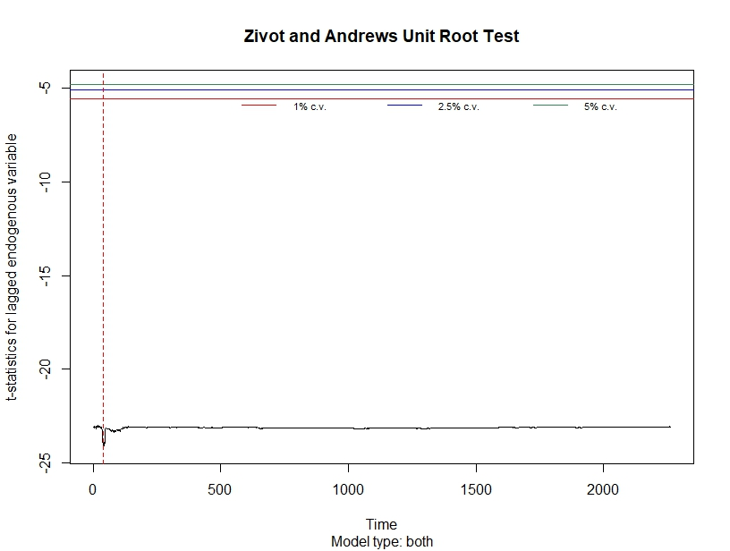

**La 39ème observation** correspond à la date du 3 mars 2009. L’actualité de Lockheed Martin ce jour-là fait état d’une fuite de données sensibles sur un hélicoptère présidentiel américain aux mains des Iraniens. Le marché a peut-être surréagi, provoquant un changement brusque dans notre série.(source)

**Conclusion**: Le test de ZA indique que la série est stationnaire avec changement structurel. Cependant, il est possible qu’il y ait eu plusieurs chocs et donc plus d’un changement structurel entre 2009 et 2017. Le test de Lee et Strazicich pourrait être utilisé pour confirmer cette conclusion, mais il n’est pas nécessaire car les trois tests de racine unitaire effectués conduisent tous à la même conclusion, **à savoir que la série est stationnaire**.

# Propriété 2: asymétrie perte/gain

Nous allons éffetuer un test de symétrie pour verifier cette propriété sur notre série. Elle consiste à tester la nullité du moment centré d’ordre 3 qui est la skewness.

Les Hypothèses:

H0: $E[(\frac{X-E(X)}{\sigma_X})^3]=0$ versus Ha: $E[(\frac{X-E(X)}{\sigma_X})^3]\neq 0$

```
D'Agostino skewness test  data:
rte skew = -0.15663, z = -3.03440, p-value = 0.00241 alternative hypothesis: data have a skewness
```

Le coefficient d’asymétrie est significatif avec une p-valeur de 0,00241, inférieure à 5 %. La valeur du coefficient d’asymétrie est de -0,15663, ce qui implique qu’il y a beaucoup plus de rendements positifs de valeurs faibles que de rendements négatifs de valeurs fortes. Cela indique que la probabilité de gains est supérieure à celle des pertes.

# Propriété 3: Queues de distribution épaisses

Le kurtosis d’une distribution est le moment d’ordre 4, qui s’apparente aux queues de la distribution. Les rendements logarithmiques ont une kurtosis plus épaisse que celle de la loi normale, qui est qualifiée de distribution leptokurtique.

H0: $E[(\frac{X-E(X)}{\sigma_X})^4]=3$ versus Ha: $E[(\frac{X-E(X)}{\sigma_X})^4]\neq 3$

```
Anscombe-Glynn kurtosis test  data:  rte
kurt = 9.0173, z = 17.1307, p-value < 2.2e-16 alternative hypothesis: kurtosis is not equal to 3
```

La p-valeur est inférieure à 2,2e-16, ce qui nous permet de rejeter l’hypothèse H0 selon laquelle les rendements suivent une distribution de la loi normale.

Le kurtosis des rendements logarithmiques de LMT est supérieur à 3 (kurtosis = 9,0173). Cela signifie que les queues des rendements de LMT sont plus épaisses que celles d’une distribution normale, ce qui est caractéristique d’une distribution leptokurtique.

# Proprité 4: Autocorrélation des carrés des rendements fortes et faibles pour les rendements

Pour déterminer l’autocorrélation des rendements et du carré des rendements, nous allons utiliser le graphique de l’ACF (autocorrélation totale) défini précédemment.( ACF)

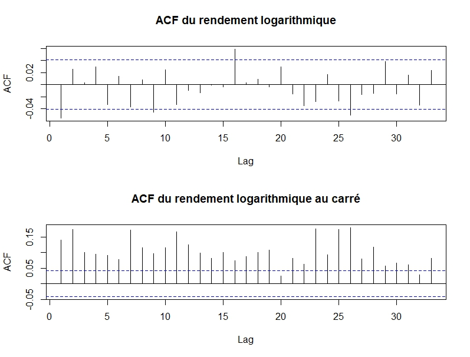

Fig 3

Commentaires:

La propriété de l’autocorrélation des carrés des rendements fortes et faibles des rendements est donc bien respectée pour notre série.

Pour nous assurer de la robustesse de resultat nous allons employer un test chiffré: le statistique de Ljung-Box

## Test de Ljung-Box sur rte² et rte:

Les hypothèses: H0: $\rho(k)=0$ pour k = 1 à K versus Ha: $\rho(k) \neq0$ pour au moins une valeur de k.

La statistique de test est : $Q_k= T(T+2)\sum_{k=1}^K \frac{\hat{\rho(k)^2}}{T-K}$ Avec $Q_k$ qui tend vers une loi de chi deux.

- Pour les **rendements au carré**, les p-values ci-dessus sont tous nulles donc < 5 %.On rejette H0, ce qui nous fait conclure au même résultat que précédement de présence d’autocorrélation dans rte².

  ```
  [1] 2.871625e-11 0.000000e+00 0.000000e+00 0.000000e+00 0.000000e+00 0.000000e+00 0.000000e+00
  [8] 0.000000e+00 0.000000e+00 0.000000e+00 0.000000e+00 0.000000e+00 0.000000e+00 0.000000e+00
  [15] 0.000000e+00 0.000000e+00 0.000000e+00 0.000000e+00 0.000000e+00 0.000000e+00 0.000000e+00
  [22] 0.000000e+00 0.000000e+00 0.000000e+00 0.000000e+00
  ```

- On rejette aussi H0 pour **les rendements** avec tous les pvalues inférieures à 5%.

  ```
  [1] 0.008485278 0.015288975 0.038793182 0.035820113 0.026075679 0.040171720 0.022861451 0.036834765
  [9] 0.012374171 0.012936584 0.009519275 0.014470710 0.019737770 0.029793265 0.042980871 0.006533409
  [17] 0.009942569 0.013993418 0.020155920 0.016973975 0.020927623 0.014439649 0.012886508 0.015285306
  [25] 0.013925956
  ```

**Conclusion**: L’ACF et la statistique de Ljung-Box montrent que l’autocorrélation est plus forte dans les rendements au carré que dans les rendements.

## Modélisation de l’autocorrélation dans les rendements

Grâce au test de racine unitaire, on sait que rte n’a pas de racine unitaire. On sait aussi, grâce aux tests de Ljung-Box, qu’il y a de l’autocorrélation dans les rendements de LMT. On peut modéliser cette autocorrélation par un processus ARMA(p,q), où p est le nombre de termes autorégressifs et q le nombre de termes de moyenne mobile. Le modèle s’écrit de la manière suivante : $1-\phi_1L-...-\phi_pL^p)y_t=\phi_0+(1-\theta_1L-...-\theta_qL^q)\epsilon_t$

Recherche des valeurs de p et de q avec le tableau de l’eacf ci- dessous:

```
AR/MA
  0 1 2 3 4 5 6 7 8 9 10 11 12 13
0 x o o o o o o o x o o  o  o  o
1 x o o o o o o o o o o  o  o  o
2 x x o o o o o o o o o  o  o  o
3 x x x o o o o o o o o  o  o  o
4 x x x x o o o o o o o  o  o  o
5 x x x x x o o o o o o  o  o  o
6 x x x o x x o o o o o  o  o  o
7 x x x x x o x o o o o  o  o  o
```

D’après le tabelaux de l’eacf ci dessus, notre série est donc un processuce moyennes mobiles MA(1) pour yt donc un ARMA(0,1).

Un MA(1) peut s’ecrire de la manière suivante: $y_t= \theta_o + \epsilon_t-\theta_1 \epsilon_{t-1}$

Estimation du modèle MA(1) de notre série rendement logarihtmique de l’action de lockeed-martin:

```
z test of coefficients:
             Estimate  Std. Error z value Pr(>|z|)
ma1       -0.05273463  0.02045826 -2.5777 0.009947 **
intercept  0.00080358  0.00024470  3.2839 0.001024 **
---
Signif. codes:  0 ‘***’ 0.001 ‘**’ 0.01 ‘*’ 0.05 ‘.’ 0.1 ‘ ’ 1
```

Pvalue de la constante $\theta_0$ est de 0.001024< 0,05, $\theta_1$ est 0.009947<0,05. Les coefficients sont donc tous significatifs. Le modèle est valide mais nous devons vérifier si les aléas du modèle on une espérance nulle et sont non-autocorrélé.

### Test d’espérance nulle des aleas :

Les hypothèses: H0: $E(\epsilon)=0$ vs H0: $E(\epsilon)\neq0$

La statistique de test est donnée par : $\frac{m(e)}{\sigma_{\varepsilon}*\sqrt{T}}$

```
        One Sample t-test
data:  residu
t = 0.00075977, df = 2263, p-value = 0.9994
alternative hypothesis: true mean is not equal to 0
95 percent confidence interval:
 -0.0005046127  0.0005050039
sample estimates:
  mean of x
1.95582e-07
```

p-value = 0.9994 > 0.05 au seuil de risque de 5%. On ne rejette pas l’hypothèse nulle de nullité de l’espèrance des aléas.

### Test d’autocorrélation de Ljung-Box sur les aleas

$H0 : ρ(1) = ... = ρ(K) = 0$ versus Ha :un des K coefficients ρ est NON nul

La statistique du test est la suivante :$Q_K = \frac{T(T+2)}{2}\sum_{k=1}^{K} \frac{\hat{\rho}(k)^2}{T-k}$

sous H0, QK suit une loi du chi-carré (K) lorsque T tend vers l’infini, où $\hat{\rho}(k)$ est l’autocorrélation à l’ordre k.

Le test est fait sur les résidus centrés réduites.

[output not shown]

**Commentaire**: Étant donné que toutes les p-values sont supérieures à 0,05, nous pouvons conclure que les résidus centrés réduits ne présentent pas de corrélation entre eux. En d’autres termes, le modèle MA(1) a donc permis de supprimer l’autocorrélation des résidus centrés réduits.

# Propriété 5 Les clusters de volatilité

Sur la figure 1, On remarque que les périodes de forte volatilité du cours de “LMT” sont groupées dans le temps, formant des clusters ou des paquets de volatilité. Cette observation est en contradiction avec l’hypothèse d’homoscédasticité conditionnelle, qui stipule que la variance des aléas au temps t est indépendante des carrés des aléas des autres périodes qui précèdent.

Nous allons utiliser le test ARCH d’Engle (LM) pour déterminer la présence ou non d’homoscédasticité conditionnelle:

- $\sigma_t^2= \alpha_0+ \alpha_1\epsilon_{t-1}^2+\alpha_2\epsilon_{t-2}^2...\alpha_m\epsilon_{t-m}^2$ la variance des aleas
- $e^2_t= a+ c_1e_{t-1}^2+....+c_pe_{t-p}^2+ erreurs$ l’équation à estimer par MCO pour obtenir la statistique de test LM

La statistique de test: $LM= N\times R^2$ avec $R^2$ le coefficient de determination de la regression sur l’equation précédente.

Les hypothèses: H0: $\alpha_1=\alpha_2...=\alpha_m$ homoscédasticité versus Ha: au moins un $\alpha_i$ est différent de 0 avec $i\neq0$ donc hétéroscédasticité conditionnelle.

```
ARCH LM-test; Null hypothesis: no ARCH effects  data:  as.numeric(rte) Chi-squared = 44.187, df = 1, p-value = 2.984e-11

ARCH LM-test; Null hypothesis: no ARCH effects  data:  as.numeric(rte) Chi-squared = 99.167, df = 2, p-value < 2.2e-16

ARCH LM-test; Null hypothesis: no ARCH effects  data:  as.numeric(rte) Chi-squared = 218.32, df = 20, p-value < 2.2e-16
```

Les p-valeurs des tests ARCH d’Engel sur les rendements de LMT sont tous inférieures à 5 %. On rejette donc H0, l’hypothèse d’homoscédasticité conditionnelle. Il y a donc une présence d’hétéroscédasticité conditionnelle et donc de clusters de volatilité dans rte.

# Propriété 6: Queues epaisses conditionnelle

La distribution des aléas corrigés des paquets de volatilité a toujours une queue plus épaisse que la loi normale, mais plus faible que celle du rendement lui-même (cas non conditionnel). Cependant, il est nécessaire de prendre en compte l’hétéroscédasticité conditionnelle en modélisant les résidus du MA(1) précédemment modélisé par un modèle GARCH(1,1). Le modèle: $\sigma_t^2= \alpha_0+\alpha_1 \epsilon_{t-1}^2+\beta_1\sigma_{t-1}^2$

```
Call:
garch(x = residuv, order = c(1, 1))

Model:
GARCH(1,1)

Residuals:
      Min        1Q    Median        3Q       Max
-6.164916 -0.548248  0.005004  0.597981  8.686712

Coefficient(s):
    Estimate  Std. Error  t value Pr(>|t|)
a0  0.020030    0.003750    5.342 9.19e-08 ***
a1  0.052495    0.005642    9.305  < 2e-16 ***
b1  0.925377    0.008752  105.739  < 2e-16 ***
---
Signif. codes:  0 ‘***’ 0.001 ‘**’ 0.01 ‘*’ 0.05 ‘.’ 0.1 ‘ ’ 1

Diagnostic Tests:
    Jarque Bera Test

data:  Residuals
X-squared = 1589.5, df = 2, p-value < 2.2e-16


    Box-Ljung test

data:  Squared.Residuals
X-squared = 0.084282, df = 1, p-value = 0.7716
```

Commentaire: les pvalues des coefficients $\beta_1,\alpha_0,\alpha_1$ sont respectivement de 2e-16,9.19e-08,2e-16 donc tous inférieures à 5%; ils sont donc significatifs. Ce qui valide le modèle. (output de l’estimation garch en annexe)

Il reste a voir si ARMA-GARCH à reussit à prendre en compte l’hétéroscédaticité conditionnelle. Pour celà nous allons effectuer le un test d’engel sur les résidus. (lien)

- Avec un retard à l’ordre 1

```
ARCH LM-test; Null hypothesis: no ARCH effects
data:  volat$res
Chi-squared = 0.08428, df = 1, p-value = 0.7716
```

- Avec un retard à l’ordre 20

```
ARCH LM-test; Null hypothesis: no ARCH effects

data:  volat$res
Chi-squared = 21.779, df = 20, p-value = 0.3526
```

Commentaire: Sur les deux tests on ne peut rejetter H0 avec des pvalues respectifs de 0.7716, et 0.3526 supérieurs à 5%. Le ARMA-GARCH/ MA(1) couplé au GARCH(1,1) à reussit a prendre en compte l’autocorrélation et l’hétéroscédasticité conditionnelle dans notre serie.

Maintenant voyons les queues de distribution du modèle, par un test de ascombe.

$$H0:
E[(\frac{X-E(X)}{\sigma_X})^4]=3$$
versus

$$Ha:E[(\frac{X-E(X)}{\sigma_X})^4]\neq
3$$

```
Anscombe-Glynn kurtosis test

data:  volat$res
kurt = 7.1057, z = 14.7676, p-value < 2.2e-16
alternative hypothesis: kurtosis is not equal to 3
```

La p-value est inférieure à 2,2e-16, qui est inférieure à 5%. Par conséquent, nous rejetons l’hypothèse nulle (H0). Cela signifie que les queues de distribution ne suivent pas la loi normale et sont même plus épaisses, avec un kurtosis de 7,10 contre 9,01 pour rte. Nous avons donc une distribution leptokurtique, mais plus faible que dans rte.

# Propriété 7: Effet de levier

L’impact du levier se manifeste lorsque les baisses du cours d’une action ont tendance à provoquer une plus grande volatilité que les hausses de cours. Cette dynamique peut être visualisée à l’aide d’un graphique qui représente à la fois l’évolution du cours et de la volatilité.

Pour quantifier la volatilité sur les 22 derniers jours, nous utilisons la statistique suivante :

$\sigma^{(22)}= \sqrt{\sum_{i=t-22}^t(y_i-(\sum_{i=t-22}^t y-i/22))^2/22}$

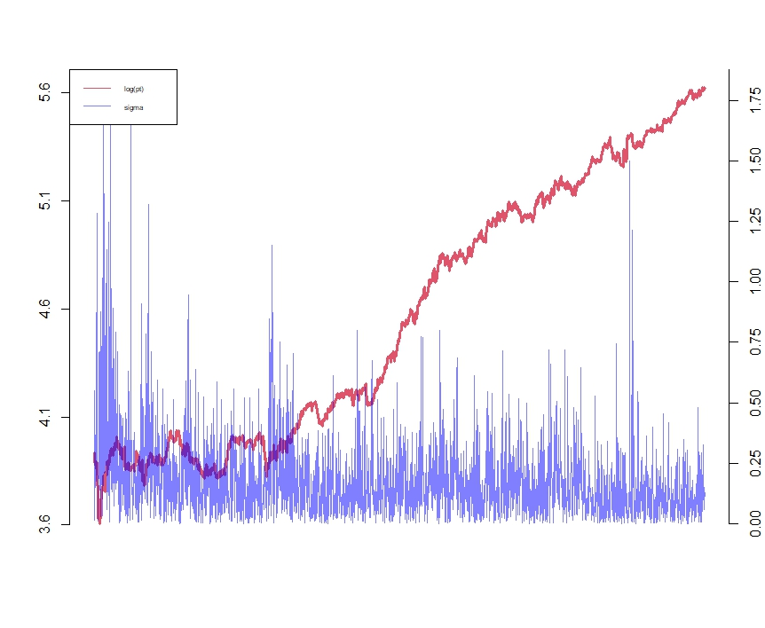

Fig 4

# Propriété 8: La saisonnalité

## Effet Weekend:

L’effet week-end sur les marchés financiers fait référence à l’influence des informations accumulées pendant les périodes de fermeture du week-end, les jours fériés et après les vacances. Selon French et Roll (1986) et Baillie et Bollerslev (1989), la variance des rendements augmente à partir du mercredi, suggérant une montée de la volatilité due à l’accumulation d’informations au cours de la semaine. Cependant, French et Roll (1986) notent que la variance des rendements est la plus élevée le lundi, indiquant des fluctuations significatives en début de semaine en raison de l’impact des événements du week-end sur les marchés. Ces observations mettent en lumière l’importance de la temporalité dans la compréhension des mouvements financiers. (Cité les text en annexe)

```
                            Monday     Tuesday    Wednesday   Thursday     Friday
moyenne en %             0.1013432  0.05861218 -0.004052305  0.1461392  0.1036438
´ecart-type annuel en % 19.9553683 19.43178826 19.313295352 19.9081231 18.7625342
skewness                 0.4241428 -0.84381082 -0.294607888  0.5592771 -0.7448192
kurtosis                10.6945763 12.39743957  6.138760529  6.1599549  9.7217912
```

## Effet Janvier

L’effet janvier, observé à Paris et à Wall Street, se réfère à la tendance favorable des actions en janvier. Il découle des opérations d’ajustement de portefeuilles effectuées par les investisseurs institutionnels en décembre, visant à vendre des titres en perte pour éviter des justifications aux assemblées générales et à générer des moins-values fiscales. Cette manipulation artificielle provoque une baisse en décembre, suivie d’une reprise en janvier. ([source](https://www.tradingsat.com/lexique-boursier/definition-effet-janvier-79.html))

Dans la figure ci-dessus, on note un pic de rendement négatif au début des mois de janvier, mais on ne distingue pas clairement des rendements plus négatifs au mois de décembre. Nous n’observons donc pas clairement l’effet janvier dans les rendements de LMT.

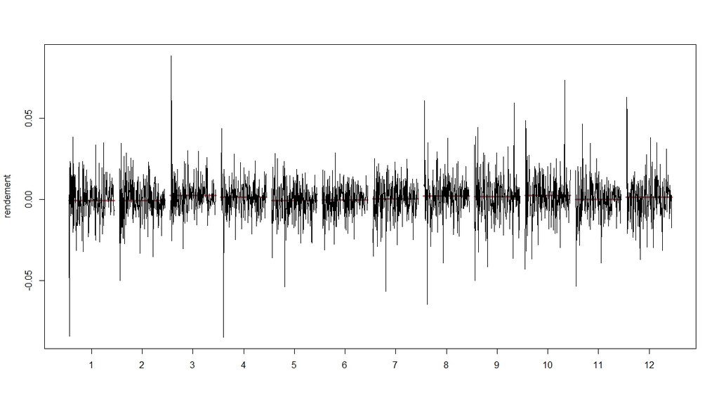

# Tableau récapitulatif:

[output not shown]

# Annexe

### Spécifications non retenues dans le test de dickey fuller

```
###############################################
# Augmented Dickey-Fuller Test Unit Root Test #
###############################################
Test regression trend

Call:
lm(formula = z.diff ~ z.lag.1 + 1 + tt)

Residuals:
      Min        1Q    Median        3Q       Max
-0.085507 -0.006373 -0.000027  0.006656  0.086872

Coefficients:
              Estimate Std. Error t value Pr(>|t|)
(Intercept)  2.865e-04  5.153e-04   0.556    0.578
z.lag.1     -1.056e+00  2.100e-02 -50.273   <2e-16 ***
tt           4.959e-07  3.944e-07   1.257    0.209
---
Signif. codes:  0 ‘***’ 0.001 ‘**’ 0.01 ‘*’ 0.05 ‘.’ 0.1 ‘ ’ 1

Residual standard error: 0.01225 on 2260 degrees of freedom
Multiple R-squared:  0.5279,    Adjusted R-squared:  0.5275
F-statistic:  1264 on 2 and 2260 DF,  p-value: < 2.2e-16

Value of test-statistic is: -50.2731 842.4622 1263.693

Critical values for test statistics:
      1pct  5pct 10pct
tau3 -3.96 -3.41 -3.12
phi2  6.09  4.68  4.03
phi3  8.27  6.25  5.34
```

**Commentaire** : P-value de $\beta1$ 0.209 > 5%. $\beta1$ n’est pas significatif. Retour au test de DF

appel

### Estimation GARCH

[output not shown]

[output cut: 39 more lines]

Retour à la propriété Queues epaisses conditionnelle

# Bibliographie

Charpentier, A. (2002), Séries Temporelles : Théorie et Applications, Polycopié de Cours, Université Paris IX Dauphine. Cours Var fiche 2

French, K. et R. Roll (1986) Stock return variances : The arrival of information and the reaction of traders, Journal of Financial Economics, 17 : P 5-26

LOCKEED MARTIN https://en.wikipedia.org/wiki/Lockheed_Martin

“Whouse helicopter data found on Iranian computer,” Stabroek News, 3 mars 2009, https://www.stabroeknews.com/2009/03/03/news/guyana/whouse-helicopter-data-found-on-iranian-computer/.